## Homework 1

*Akshay Kumar Varanasi (av32826)*

**This homework is due on Jan. 29, 2019 at 4:00 pm. Please submit as a pdf file on Canvas.**

This homework uses the `ToothGrowth` dataset. This dataset is built into R, and it contains the lengths (`len`) of odontoblasts (cells responsible for tooth growth) in 60 quinea pigs. Each animal received one of the three dose levels (`dose`) of vitamin C in mg/day: 0.5, 1, or 2. Vitamin C was delivered either through orange juice or through ascorbic acid supplement (`supp`).

```r
head(ToothGrowth)
```

```
##    len supp dose
## 1  4.2   VC  0.5
## 2 11.5   VC  0.5
## 3  7.3   VC  0.5
## 4  5.8   VC  0.5
## 5  6.4   VC  0.5
## 6 10.0   VC  0.5
```

**Problem 1: (4 pts)** We are interested in testing the effects of vitamin C on odontoblasts growths in guinea pigs. Since there are three different doses of vitamin C in the data set, and therefore three groups of length measurements, we will use an analysis of variance (ANOVA) test. Conduct an ANOVA test and interpret your results in 1-2 sentences. HINT: You will first need to create a linear model object using the `lm()` function before you can use the `anova()` function.

```r
fit<-lm(len~dose,data=ToothGrowth)
anova(fit)
```

```
## Analysis of Variance Table
##
## Response: len
##           Df Sum Sq Mean Sq F value    Pr(>F)
## dose       1 2224.3 2224.30  105.06 1.233e-14 ***
## Residuals 58 1227.9   21.17
## ---
## Signif. codes:  0 '***' 0.001 '**' 0.01 '*' 0.05 '.' 0.1 ' ' 1
```

Since the P-value is very less, we can reject the Null hypothesis and conclude that length of odontoblasts differs significantly based on dosage.

**Problem 2: (3 pts)** Create a boxplot of the teeth growth, separated by vitamin C doses. Based on this plot, do you expect the mean length of odontoblasts for the 2 mg/day dose to be the same or different than the mean length of odontoblasts for the 0.5 mg/day dose? Explain your answer.

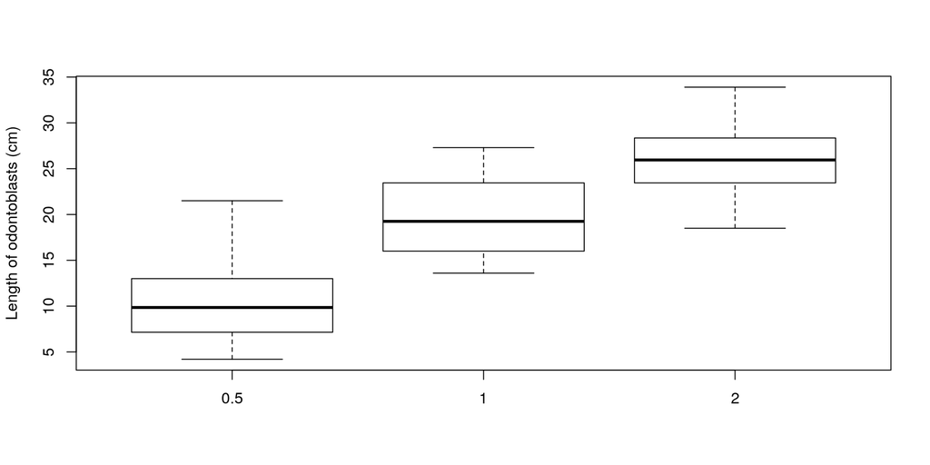

```r
# dose_0.5<-ToothGrowth$len[ToothGrowth$dose=='0.5']
# dose_1<-ToothGrowth$len[ToothGrowth$dose=='1']
# dose_2<-ToothGrowth$len[ToothGrowth$dose=='2']
# boxplot(dose_0.5,dose_1,dose_2,names = c('0.5 mg/day','1 mg/day','2 mg/day'))
#

boxplot(ToothGrowth$len ~ ToothGrowth$dose,ylab="Length of odontoblasts (cm)")
```

Similar to the anova results, the length differs significantly based on dosage and therefore also its mean.

**Problem 3: (3 pts)** Use a t test to determine if the mean length of odontoblasts for the 2 mg/day dose is the same as or different from the mean length of odontoblasts for 0.5 mg/day. Interperet and explain your results in 1-2 sentences.

```r
dose_0.5<-ToothGrowth$len[ToothGrowth$dose=='0.5']
dose_1<-ToothGrowth$len[ToothGrowth$dose=='1']
dose_2<-ToothGrowth$len[ToothGrowth$dose=='2']
t.test(dose_0.5,dose_2)
```

```
##
##  Welch Two Sample t-test
##
## data:  dose_0.5 and dose_2
## t = -11.799, df = 36.883, p-value = 4.398e-14
## alternative hypothesis: true difference in means is not equal to 0
## 95 percent confidence interval:
##  -18.15617 -12.83383
## sample estimates:
## mean of x mean of y
##    10.605    26.100
```

T-test reassures our above findings that the means are different as P-value is very low